# Q & K Box 13.8

Ryeland et al (2017) studied the roosting behaviour of several species of shorebirds. They recorded the proportion of time (number of minutes as a proportion of total minutes in a video bout) individuals of various species spent in the backrest position while roosting. They used a binomial model with a logit link for proportions with four fixed predictors recorded for each video bout: ambient temperature, wind speed, size of group focal bird was in, and distance focal bird was from the observer. We will analyze the data for a single species, the sharp-tailed sandpiper (*Calidris acuminata*). This would be a standard binomial GLM except that more than one bird was sometimes recorded in each bout so bout was included as a random effect since birds closer together may be correlated in their behaviour. The resulting model is a binomial GLMM.

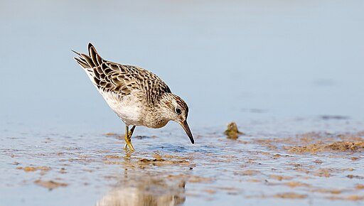

Sharp-tailed sandpiper. patrickkavanagh, , via Wikimedia Commons

The paper is [here](https://doi.org/10.1111/1365-2435.12814)

Ryeland, J., Weston, M. A., Symonds, M. R. E. & Overgaard, J. (2017). Bill size mediates behavioural thermoregulation in birds. *Functional Ecology*, 31, 885-93.

### Preliminaries

First, load the required packages (car, performance, MuMIn, lme4, glmmTMB, lmtest, ggplot2)

Import ryeland data file (ryeland.csv)

```r
ryeland <- read.csv("../data/ryeland.csv")
head(ryeland)
```

|  | dist | groupsize | temp | wind | filmp | timehb | vbout | olre |
| --- | --- | --- | --- | --- | --- | --- | --- | --- |
| 1 | 30 | 40 | 15.4 | 2.08 | 9.49 | 0.00 | s1 | 1 |
| 2 | 30 | 40 | 15.4 | 2.08 | 13.09 | 11.42 | s1 | 2 |
| 3 | 50 | 20 | 15.6 | 3.22 | 22.55 | 18.46 | s6 | 3 |
| 4 | 50 | 20 | 15.6 | 3.22 | 22.55 | 15.07 | s6 | 4 |
| 5 | 50 | 30 | 15.3 | 2.90 | 5.03 | 1.22 | s7 | 5 |
| 6 | 50 | 30 | 15.3 | 2.90 | 5.03 | 1.22 | s7 | 6 |

Create proportion of time facing back

```r
ryeland$prophb<-ryeland$timehb/ryeland$filmp
```

Create success and fail columns

```r
ryeland$success<-as.integer(ryeland$timehb)
ryeland$fail<-as.integer(ryeland$filmp-ryeland$timehb)
```

Create response variable

```r
ryeland.prop<-cbind(ryeland$success,ryeland$fail)
```

### Preliminary checks

Scatterplots

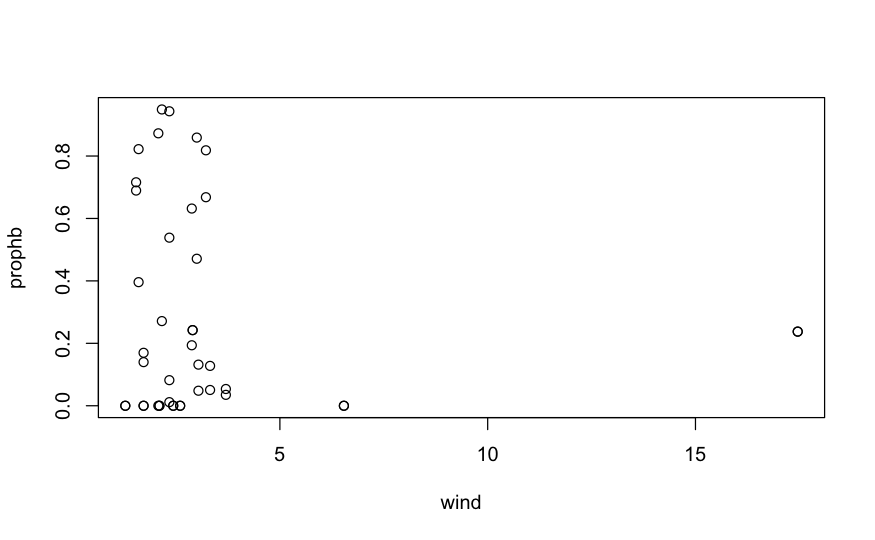

```r
plot(prophb~wind, data=ryeland)
```

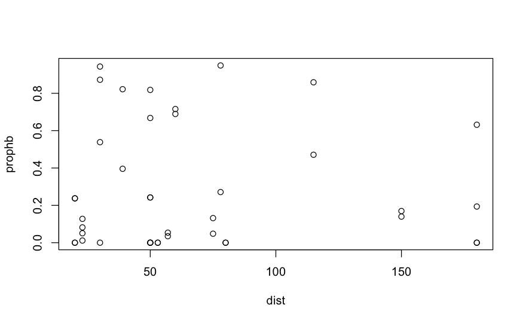

```r
plot(prophb~dist, data=ryeland)
```

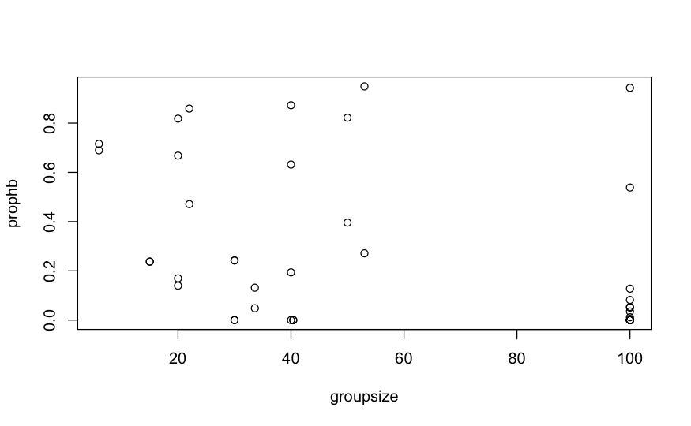

```r
plot(prophb~groupsize, data=ryeland)
```

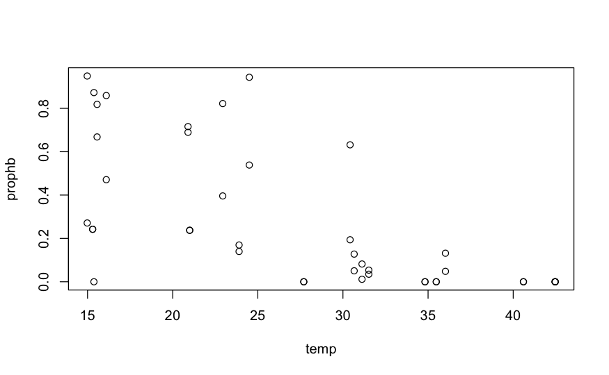

```r
plot(prophb~temp, data=ryeland)
```

Boxplots

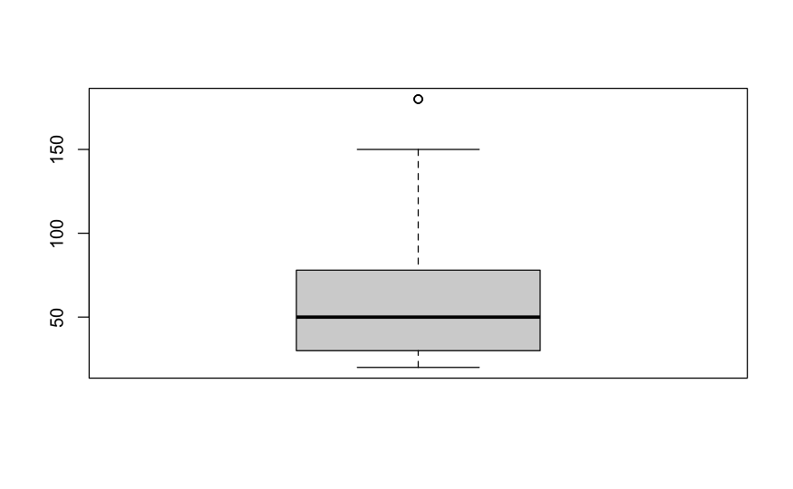

```r
boxplot(ryeland$dist)
```

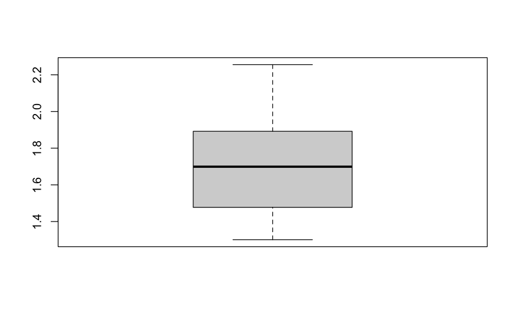

```r
boxplot(log10(ryeland$dist))
```

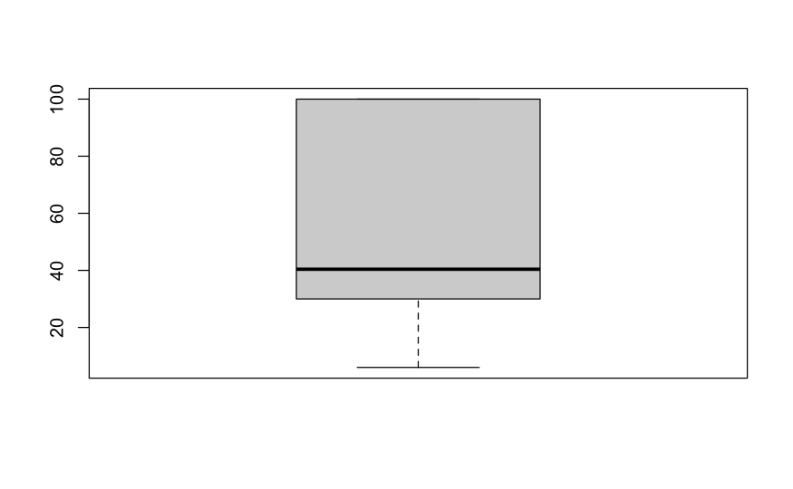

```r
boxplot(ryeland$groupsize)
```

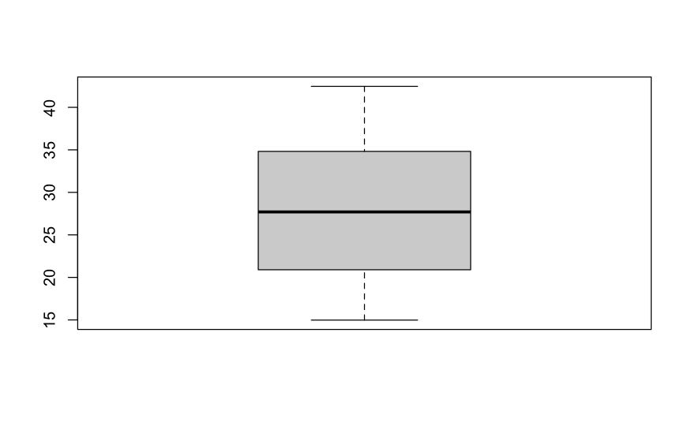

```r
boxplot(ryeland$temp)
```

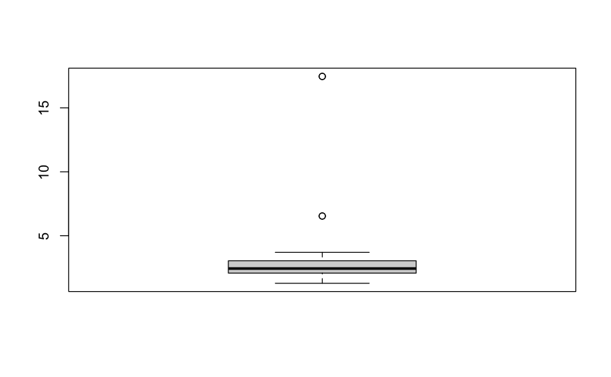

```r
boxplot(ryeland$wind)
```

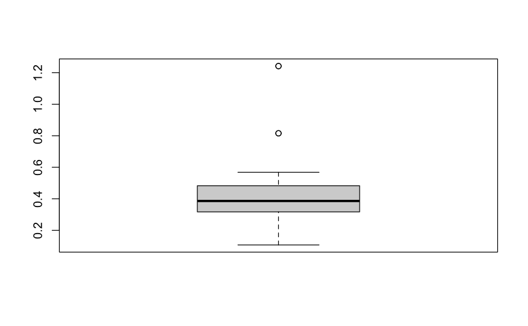

```r
boxplot(log10(ryeland$wind))
```

Check collinearity

```r
vif(lm(ryeland$prophb ~ dist+groupsize+temp+wind,data=ryeland))
```

```
     dist groupsize      temp      wind
     1.23      2.03      1.85      1.16
```

```r
cor(ryeland[,c('dist','groupsize','temp','wind')])
```

```
             dist groupsize    temp   wind
dist       1.0000    -0.203  0.0162 -0.274
groupsize -0.2030     1.000  0.6525 -0.157
temp       0.0162     0.652  1.0000 -0.047
wind      -0.2738    -0.157 -0.0470  1.000
```

### Fit GLMM with binomial distribution and test predictor effects

```r
ryeland1.glmer<-glmer(ryeland.prop~dist+groupsize+temp+wind+(1|vbout),data=ryeland,family=binomial)
summary(ryeland1.glmer)
```

```
Generalized linear mixed model fit by maximum likelihood (Laplace Approximation) ['glmerMod']
 Family: binomial  ( logit )
Formula: ryeland.prop ~ dist + groupsize + temp + wind + (1 | vbout)
   Data: ryeland

     AIC      BIC   logLik deviance df.resid
     224      234     -106      212       36

Scaled residuals:
   Min     1Q Median     3Q    Max
-3.529 -0.697 -0.221  0.408  3.338

Random effects:
 Groups Name        Variance Std.Dev.
 vbout  (Intercept) 1.43     1.19
Number of obs: 42, groups:  vbout, 21

Fixed effects:
            Estimate Std. Error z value Pr(>|z|)
(Intercept)  4.46783    1.23192    3.63  0.00029 ***
dist         0.00364    0.00770    0.47  0.63666
groupsize    0.00316    0.01311    0.24  0.80938
temp        -0.24929    0.05531   -4.51  6.6e-06 ***
wind        -0.03106    0.09391   -0.33  0.74084
---
Signif. codes:  0 ‘***’ 0.001 ‘**’ 0.01 ‘*’ 0.05 ‘.’ 0.1 ‘ ’ 1

Correlation of Fixed Effects:
          (Intr) dist   gropsz temp
dist      -0.375
groupsize -0.155  0.453
temp      -0.551 -0.362 -0.597
wind      -0.395  0.387  0.345 -0.200
```

```r
AIC(ryeland1.glmer)
```

```
[1] 224
```

```r
AICc(ryeland1.glmer)
```

```
[1] 226
```

```r
anova(ryeland1.glmer, type="lrtest")
```

```
Analysis of Variance Table
          npar Sum Sq Mean Sq F value
dist         1   0.08    0.08    0.08
groupsize    1   8.33    8.33    8.33
temp         1  22.00   22.00   22.00
wind         1   0.11    0.11    0.11
```

Test wind

```r
ryeland2.glmer<-glmer(ryeland.prop~dist+groupsize+temp+(1|vbout),data=ryeland,family=binomial)
lrtest(ryeland1.glmer, ryeland2.glmer)
```

```
Likelihood ratio test

Model 1: ryeland.prop ~ dist + groupsize + temp + wind + (1 | vbout)
Model 2: ryeland.prop ~ dist + groupsize + temp + (1 | vbout)
  #Df LogLik Df Chisq Pr(>Chisq)
1   6   -106
2   5   -106 -1  0.11       0.74
```

Test temp

```r
ryeland3.glmer<-glmer(ryeland.prop~dist+groupsize+wind+(1|vbout),data=ryeland,family=binomial)
lrtest(ryeland1.glmer, ryeland3.glmer)
```

```
Likelihood ratio test

Model 1: ryeland.prop ~ dist + groupsize + temp + wind + (1 | vbout)
Model 2: ryeland.prop ~ dist + groupsize + wind + (1 | vbout)
  #Df LogLik Df Chisq Pr(>Chisq)
1   6   -106
2   5   -115 -1  17.4      3e-05 ***
---
Signif. codes:  0 ‘***’ 0.001 ‘**’ 0.01 ‘*’ 0.05 ‘.’ 0.1 ‘ ’ 1
```

Test groupsize

```r
ryeland4.glmer<-glmer(ryeland.prop~dist+temp+wind+(1|vbout),data=ryeland,family=binomial)
lrtest(ryeland1.glmer, ryeland4.glmer)
```

```
Likelihood ratio test

Model 1: ryeland.prop ~ dist + groupsize + temp + wind + (1 | vbout)
Model 2: ryeland.prop ~ dist + temp + wind + (1 | vbout)
  #Df LogLik Df Chisq Pr(>Chisq)
1   6   -106
2   5   -106 -1  0.06       0.81
```

Test dist

```r
ryeland5.glmer<-glmer(ryeland.prop~groupsize+wind+temp+wind+(1|vbout),data=ryeland,family=binomial)
lrtest(ryeland1.glmer, ryeland5.glmer)
```

```
Likelihood ratio test

Model 1: ryeland.prop ~ dist + groupsize + temp + wind + (1 | vbout)
Model 2: ryeland.prop ~ groupsize + wind + temp + wind + (1 | vbout)
  #Df LogLik Df Chisq Pr(>Chisq)
1   6   -106
2   5   -106 -1  0.22       0.64
```

Check residuals

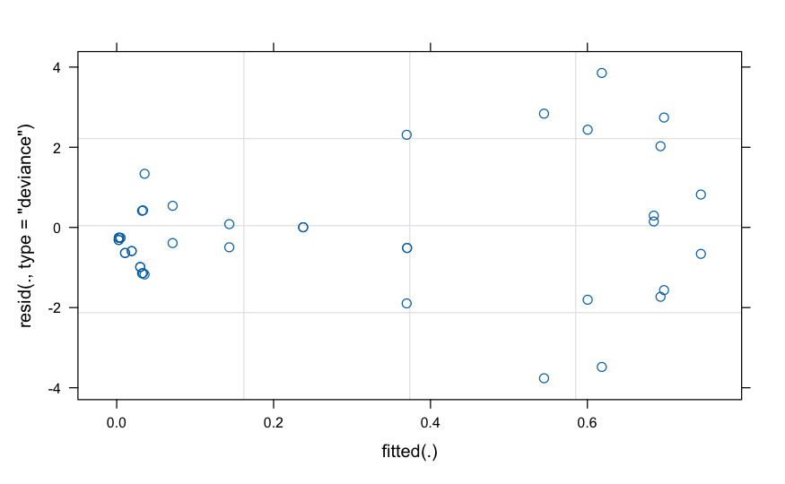

```r
plot(ryeland1.glmer, resid(., type = "deviance") ~ fitted(.))
```

```r
residuals(ryeland1.glmer, type="deviance")
```

```
      1       2       3       4       5       6       7       8       9      10      11      12      13      14      15      16      17      18      19      20      21      22
-3.7634  2.8380  0.8204 -0.6598 -0.5124 -0.5124  3.8535 -3.4811 -1.7306  2.0263  2.7415 -1.5641  0.2951  0.1486 -0.9874 -0.9874  0.0823 -0.4955  0.4147 -1.1464  2.3104 -1.8960
     23      24      25      26      27      28      29      30      31      32      33      34      35      36      37      38      39      40      41      42
-0.5897 -0.5897 -1.1729  1.3381  0.0043  0.0043 -0.2598 -0.2598 -0.3127 -0.3127 -0.2564 -0.2564 -1.8043  2.4378 -0.3901  0.5396  0.4258 -1.1398 -0.6372 -0.6372
```

### Check overdispersion

(code from Zuur et al 2013)

```r
presid1 <- resid(ryeland1.glmer, type="pearson")
ssize1 <- nrow(ryeland)
params1 <- length(fixef(ryeland1.glmer)+1)
disp1 <- sum(presid1^2)/(ssize1-params1)
disp1
```

```
[1] 2.23
```

### Add Observation Level Random Effect into model and retest the predictors

```r
ryeland6.glmer<-glmer(ryeland.prop~dist+groupsize+temp+wind+(1|vbout)+(1|olre),data=ryeland,family=binomial)
summary(ryeland6.glmer)
```

```
Generalized linear mixed model fit by maximum likelihood (Laplace Approximation) ['glmerMod']
 Family: binomial  ( logit )
Formula: ryeland.prop ~ dist + groupsize + temp + wind + (1 | vbout) +      (1 | olre)
   Data: ryeland

     AIC      BIC   logLik deviance df.resid
     176      188      -81      162       35

Scaled residuals:
   Min     1Q Median     3Q    Max
-1.129 -0.365 -0.110  0.146  0.806

Random effects:
 Groups Name        Variance Std.Dev.
 olre   (Intercept) 2.282    1.511
 vbout  (Intercept) 0.653    0.808
Number of obs: 42, groups:  olre, 42; vbout, 21

Fixed effects:
            Estimate Std. Error z value Pr(>|z|)
(Intercept)  5.03538    1.39144    3.62   0.0003 ***
dist         0.00488    0.00859    0.57   0.5695
groupsize    0.00664    0.01469    0.45   0.6511
temp        -0.28931    0.06361   -4.55  5.4e-06 ***
wind        -0.02193    0.10482   -0.21   0.8343
---
Signif. codes:  0 ‘***’ 0.001 ‘**’ 0.01 ‘*’ 0.05 ‘.’ 0.1 ‘ ’ 1

Correlation of Fixed Effects:
          (Intr) dist   gropsz temp
dist      -0.355
groupsize -0.125  0.448
temp      -0.567 -0.368 -0.607
wind      -0.387  0.391  0.344 -0.203
optimizer (Nelder_Mead) convergence code: 0 (OK)
Model failed to converge with max|grad| = 0.00479232 (tol = 0.002, component 1)
```

```r
AIC(ryeland6.glmer)
```

```
[1] 176
```

```r
AICc(ryeland6.glmer)
```

```
[1] 179
```

Test wind

```r
ryeland7.glmer<-glmer(ryeland.prop~dist+groupsize+temp+(1|vbout)+(1|olre),data=ryeland,family=binomial)
lrtest(ryeland6.glmer, ryeland7.glmer)
```

```
Likelihood ratio test

Model 1: ryeland.prop ~ dist + groupsize + temp + wind + (1 | vbout) +
    (1 | olre)
Model 2: ryeland.prop ~ dist + groupsize + temp + (1 | vbout) + (1 | olre)
  #Df LogLik Df Chisq Pr(>Chisq)
1   7    -81
2   6    -81 -1  0.04       0.83
```

Test temp

```r
ryeland8.glmer<-glmer(ryeland.prop~dist+groupsize+wind+(1|vbout)+(1|olre),data=ryeland,family=binomial)
lrtest(ryeland6.glmer, ryeland8.glmer)
```

```
Likelihood ratio test

Model 1: ryeland.prop ~ dist + groupsize + temp + wind + (1 | vbout) +
    (1 | olre)
Model 2: ryeland.prop ~ dist + groupsize + wind + (1 | vbout) + (1 | olre)
  #Df LogLik Df Chisq Pr(>Chisq)
1   7  -81.0
2   6  -90.1 -1  18.2      2e-05 ***
---
Signif. codes:  0 ‘***’ 0.001 ‘**’ 0.01 ‘*’ 0.05 ‘.’ 0.1 ‘ ’ 1
```

Test groupsize

```r
ryeland9.glmer<-glmer(ryeland.prop~dist+temp+wind+(1|vbout)+(1|olre),data=ryeland,family=binomial)
lrtest(ryeland6.glmer, ryeland9.glmer)
```

```
Likelihood ratio test

Model 1: ryeland.prop ~ dist + groupsize + temp + wind + (1 | vbout) +
    (1 | olre)
Model 2: ryeland.prop ~ dist + temp + wind + (1 | vbout) + (1 | olre)
  #Df LogLik Df Chisq Pr(>Chisq)
1   7  -81.0
2   6  -81.1 -1   0.2       0.65
```

Test dist

```r
ryeland10.glmer<-glmer(ryeland.prop~groupsize+wind+temp+wind+(1|vbout)+(1|olre),data=ryeland,family=binomial)
lrtest(ryeland6.glmer, ryeland10.glmer)
```

```
Likelihood ratio test

Model 1: ryeland.prop ~ dist + groupsize + temp + wind + (1 | vbout) +
    (1 | olre)
Model 2: ryeland.prop ~ groupsize + wind + temp + wind + (1 | vbout) +
    (1 | olre)
  #Df LogLik Df Chisq Pr(>Chisq)
1   7  -81.0
2   6  -81.1 -1  0.32       0.57
```

Check residuals

```r
residuals(ryeland6.glmer, type="deviance")
```

```
        1         2         3         4         5         6         7         8         9        10        11        12        13        14        15        16        17        18
-1.544739  0.517286  0.119681 -0.032263 -0.468487 -0.468487  0.532565 -0.413694 -0.252082  0.424475  0.888607  0.099123  0.205676  0.194426 -0.863413 -0.863413 -0.092399 -0.205755
       19        20        21        22        23        24        25        26        27        28        29        30        31        32        33        34        35        36
 0.129297 -0.810856  0.465602  0.081393 -0.519161 -0.519161 -0.556220  0.670993  0.008321  0.008321 -0.193177 -0.193177 -0.229764 -0.229764 -0.180583 -0.180583  0.021693  0.501009
       37        38        39        40        41        42
 0.000936  0.219131  0.147782 -0.798193 -0.502843 -0.502843
```

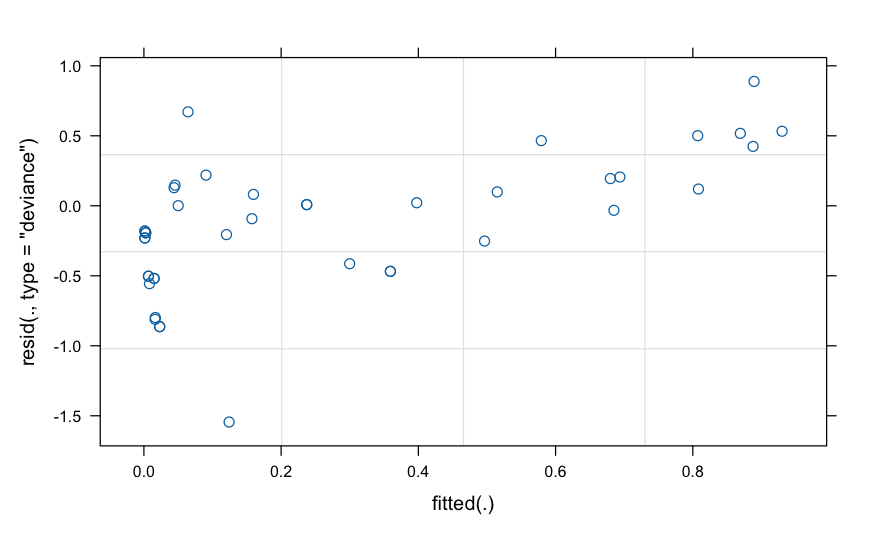

```r
plot(ryeland6.glmer, resid(., type = "deviance") ~ fitted(.))
```

### Fit model with only temp to match paper

```r
ryeland11.glmer<-glmer(ryeland.prop~temp+(1|vbout)+(1|olre),data=ryeland,family=binomial)
summary(ryeland11.glmer)
```

```
Generalized linear mixed model fit by maximum likelihood (Laplace Approximation) ['glmerMod']
 Family: binomial  ( logit )
Formula: ryeland.prop ~ temp + (1 | vbout) + (1 | olre)
   Data: ryeland

     AIC      BIC   logLik deviance df.resid
   170.6    177.5    -81.3    162.6       38

Scaled residuals:
   Min     1Q Median     3Q    Max
-1.128 -0.350 -0.108  0.163  0.812

Random effects:
 Groups Name        Variance Std.Dev.
 olre   (Intercept) 2.264    1.505
 vbout  (Intercept) 0.781    0.884
Number of obs: 42, groups:  olre, 42; vbout, 21

Fixed effects:
            Estimate Std. Error z value Pr(>|z|)
(Intercept)   5.1380     1.2625    4.07  4.7e-05 ***
temp         -0.2701     0.0508   -5.31  1.1e-07 ***
---
Signif. codes:  0 ‘***’ 0.001 ‘**’ 0.01 ‘*’ 0.05 ‘.’ 0.1 ‘ ’ 1

Correlation of Fixed Effects:
     (Intr)
temp -0.953
```

```r
AIC(ryeland11.glmer)
```

```
[1] 171
```

```r
AICc(ryeland11.glmer)
```

```
[1] 172
```

Plot temp to match paper **Need to add fit logistic curve?**

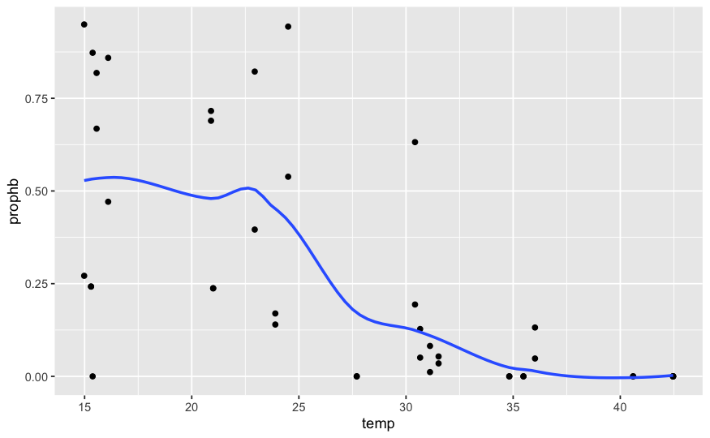

```r
ggplot(ryeland, aes(temp, prophb)) + geom_point() +
  geom_smooth(method = "loess", span = 0.5, se = FALSE)
```

```r
ryeland.glmmb <- glmmTMB(ryeland.prop~groupsize+wind+temp+wind+(1|vbout), family=binomial, data=ryeland)
summary(ryeland.glmmb)
```

```
 Family: binomial  ( logit )
Formula:          ryeland.prop ~ groupsize + wind + temp + wind + (1 | vbout)
Data: ryeland

     AIC      BIC   logLik deviance df.resid
     222      231     -106      212       37

Random effects:

Conditional model:
 Groups Name        Variance Std.Dev.
 vbout  (Intercept) 1.45     1.2
Number of obs: 42, groups:  vbout, 21

Conditional model:
            Estimate Std. Error z value Pr(>|z|)
(Intercept)  4.69865    1.14625    4.10  4.1e-05 ***
groupsize    0.00034    0.01174    0.03     0.98
wind        -0.04793    0.08722   -0.55     0.58
temp        -0.24056    0.05164   -4.66  3.2e-06 ***
---
Signif. codes:  0 ‘***’ 0.001 ‘**’ 0.01 ‘*’ 0.05 ‘.’ 0.1 ‘ ’ 1
```

### Now fit betabinomial to compare to OLRE

```r
ryeland.glmmbb <- glmmTMB(ryeland.prop~dist+groupsize+temp+wind+(1|vbout),data=ryeland,family=betabinomial(link="logit"))
summary(ryeland.glmmbb)
```

```
 Family: betabinomial  ( logit )
Formula:          ryeland.prop ~ dist + groupsize + temp + wind + (1 | vbout)
Data: ryeland

     AIC      BIC   logLik deviance df.resid
   178.7    190.8    -82.3    164.7       35

Random effects:

Conditional model:
 Groups Name        Variance Std.Dev.
 vbout  (Intercept) 0.124    0.353
Number of obs: 42, groups:  vbout, 21

Dispersion parameter for betabinomial family ():  2.6

Conditional model:
            Estimate Std. Error z value Pr(>|z|)
(Intercept)  3.39744    1.02782    3.31  0.00095 ***
dist         0.00215    0.00601    0.36  0.72045
groupsize    0.00685    0.00984    0.70  0.48647
temp        -0.19311    0.04846   -3.98  6.8e-05 ***
wind        -0.01632    0.06696   -0.24  0.80738
---
Signif. codes:  0 ‘***’ 0.001 ‘**’ 0.01 ‘*’ 0.05 ‘.’ 0.1 ‘ ’ 1
```

```r
AICc(ryeland.glmmbb)
```

```
[1] 182
```

Test temperature

```r
ryeland1.glmmbb <- glmmTMB(ryeland.prop~dist+groupsize+wind+(1|vbout),data=ryeland,family=betabinomial(link="logit"))
lrtest(ryeland.glmmbb, ryeland1.glmmbb)
```

```
Likelihood ratio test

Model 1: ryeland.prop ~ dist + groupsize + temp + wind + (1 | vbout)
Model 2: ryeland.prop ~ dist + groupsize + wind + (1 | vbout)
  #Df LogLik Df Chisq Pr(>Chisq)
1   7  -82.3
2   6  -91.9 -1  19.1    1.2e-05 ***
---
Signif. codes:  0 ‘***’ 0.001 ‘**’ 0.01 ‘*’ 0.05 ‘.’ 0.1 ‘ ’ 1
```